# Titanic

Authors

Gema Fernández-Avilés

Isidro Higalgo

Published

December 18, 2024

**Note**

Titanic dataset de kaggel

```r
library(titanic)
library(tidyverse)
head(titanic_train)
```

```
  PassengerId Survived Pclass
1           1        0      3
2           2        1      1
3           3        1      3
4           4        1      1
5           5        0      3
6           6        0      3
                                                 Name    Sex Age SibSp Parch
1                             Braund, Mr. Owen Harris   male  22     1     0
2 Cumings, Mrs. John Bradley (Florence Briggs Thayer) female  38     1     0
3                              Heikkinen, Miss. Laina female  26     0     0
4        Futrelle, Mrs. Jacques Heath (Lily May Peel) female  35     1     0
5                            Allen, Mr. William Henry   male  35     0     0
6                                    Moran, Mr. James   male  NA     0     0
            Ticket    Fare Cabin Embarked
1        A/5 21171  7.2500              S
2         PC 17599 71.2833   C85        C
3 STON/O2. 3101282  7.9250              S
4           113803 53.1000  C123        S
5           373450  8.0500              S
6           330877  8.4583              Q
```

```r
datos_titanic <- titanic_train
```

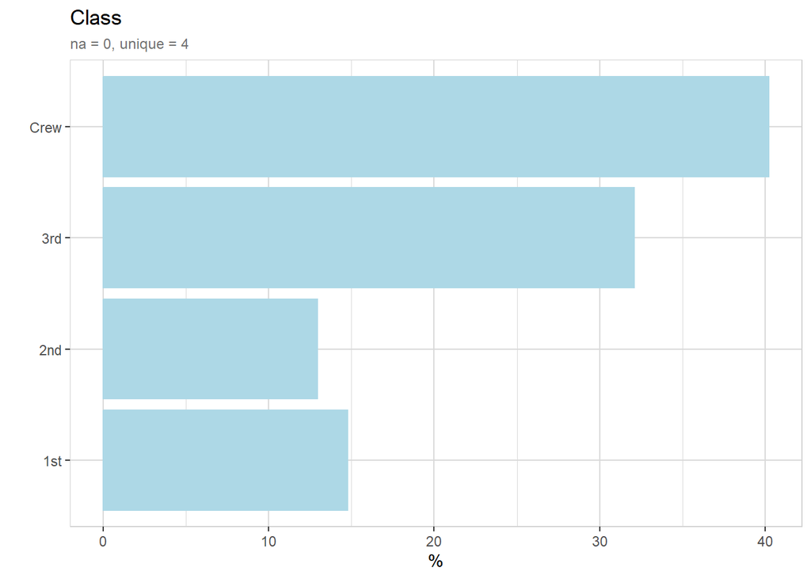

```r
library(explore)
titanic <- use_data_titanic(count = TRUE)
 titanic |> explore(Class, n = n)
```

```r
 titanic |> describe(Class, n = n)
```

```
variable = Class
type     = character
na       = 0 of 2 201 (0%)
unique   = 4
 1st     = 325 (14.8%)
 2nd     = 285 (12.9%)
 3rd     = 706 (32.1%)
 Crew    = 885 (40.2%)
```

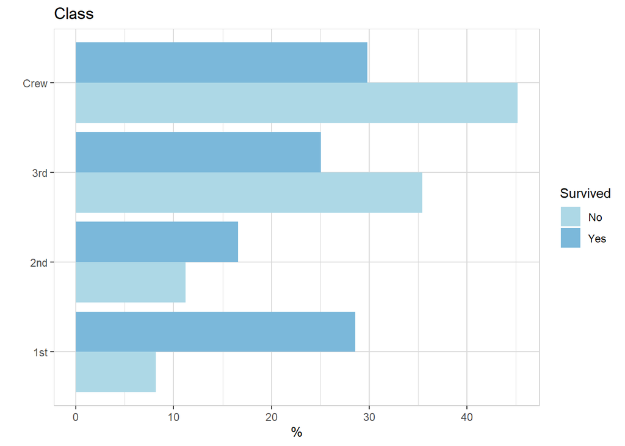

```r
titanic |> explore(Class, target = Survived, n = n, split = TRUE)
```

Todas

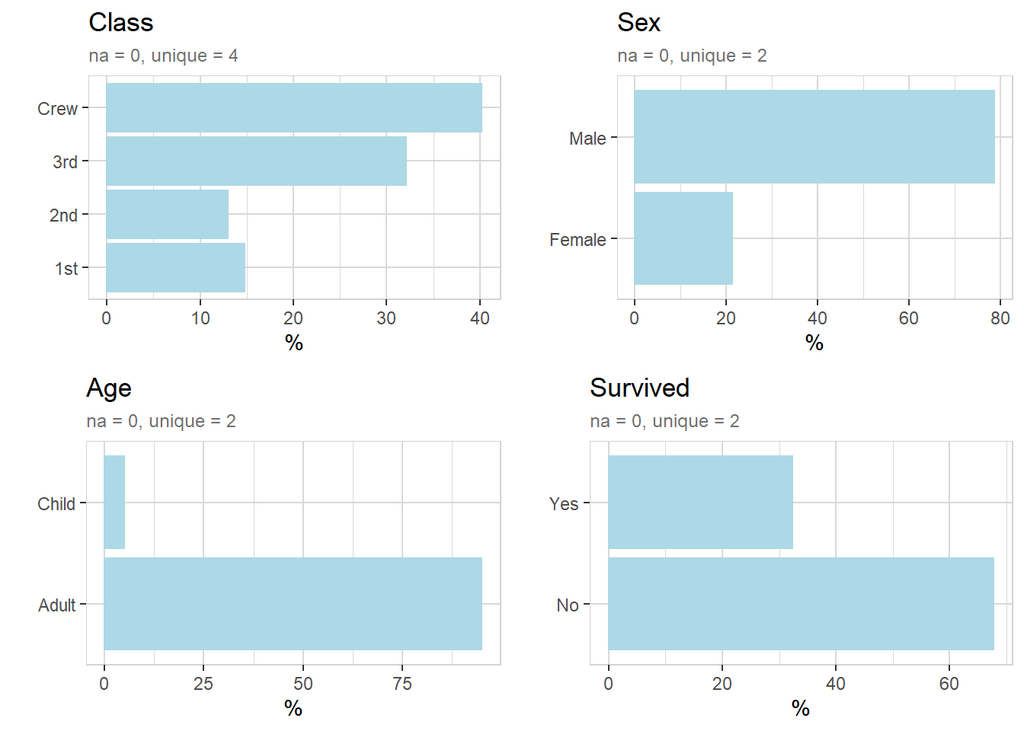

```r
titanic |> explore_all(n = n)
```

```r
## ........................ TITANIC

datos_titanic<- datos_titanic
skimr::skim(datos_titanic)
```

Data summary

| Name | datos_titanic |
| --- | --- |
| Number of rows | 891 |
| Number of columns | 12 |
| _______________________ |  |
| Column type frequency: |  |
| character | 5 |
| numeric | 7 |
| ________________________ |  |
| Group variables | None |

**Variable type: character**

| skim_variable | n_missing | complete_rate | min | max | empty | n_unique | whitespace |
| --- | --- | --- | --- | --- | --- | --- | --- |
| Name | 0 | 1 | 12 | 82 | 0 | 891 | 0 |
| Sex | 0 | 1 | 4 | 6 | 0 | 2 | 0 |
| Ticket | 0 | 1 | 3 | 18 | 0 | 681 | 0 |
| Cabin | 0 | 1 | 0 | 15 | 687 | 148 | 0 |
| Embarked | 0 | 1 | 0 | 1 | 2 | 4 | 0 |

**Variable type: numeric**

| skim_variable | n_missing | complete_rate | mean | sd | p0 | p25 | p50 | p75 | p100 | hist |
| --- | --- | --- | --- | --- | --- | --- | --- | --- | --- | --- |
| PassengerId | 0 | 1.0 | 446.00 | 257.35 | 1.00 | 223.50 | 446.00 | 668.5 | 891.00 | ▇▇▇▇▇ |
| Survived | 0 | 1.0 | 0.38 | 0.49 | 0.00 | 0.00 | 0.00 | 1.0 | 1.00 | ▇▁▁▁▅ |
| Pclass | 0 | 1.0 | 2.31 | 0.84 | 1.00 | 2.00 | 3.00 | 3.0 | 3.00 | ▃▁▃▁▇ |
| Age | 177 | 0.8 | 29.70 | 14.53 | 0.42 | 20.12 | 28.00 | 38.0 | 80.00 | ▂▇▅▂▁ |
| SibSp | 0 | 1.0 | 0.52 | 1.10 | 0.00 | 0.00 | 0.00 | 1.0 | 8.00 | ▇▁▁▁▁ |
| Parch | 0 | 1.0 | 0.38 | 0.81 | 0.00 | 0.00 | 0.00 | 0.0 | 6.00 | ▇▁▁▁▁ |
| Fare | 0 | 1.0 | 32.20 | 49.69 | 0.00 | 7.91 | 14.45 | 31.0 | 512.33 | ▇▁▁▁▁ |

Mosaico: las dos variables cualitativas

Un diagrama de mosaico es un método gráfico para visualizar datos de dos o más variables cualitativas. Ofrece una visión general de los datos y permite reconocer relaciones entre diferentes variables cualitativas.

Veamos la supervivencia o no de los pasajeros del Titanic en función del Sexo (ambas variables cualitativas)

```r
library(ggmosaic)

g_mosaico= ggplot(data = datos_titanic) +
   geom_mosaic(aes(x = product(`Survived`, `Sex`),
                   fill=`Survived`)) +
   theme(axis.text.y = element_text(size = 5))     +
   labs(title=' ')

g_mosaico
```

[output not shown]

### 0.0.1 Mosaico: las tres variables cualitativas

Avanzamos un poco más con los gráficos de mosaico, representando tres variables cualitativas.

Veamos la supervivencia o no de los pasajeros del Titanic en función del Sexo y la clase (todas las variables cualitativas)

```r
library(ggplot2)
library(ggmosaic)

ggplot(data = datos_titanic) +
   geom_mosaic(aes(x = product(`Survived`, `Sex`, `Pclass` ),
                   fill=`Survived`)) +
   theme(axis.text.y = element_text(size = 5))     +
   labs(title=' ')
```

[output not shown]

### 0.0.2 Diagramas de flujo

Un diagrama de flujo es un gráfico que muestra los pasos de un proceso de una manera visual y fácil de entender, por tanto, este tipo de gráficos permitirán visualizar el flujo de los datos en el plot. Véase como mejora la interpretabilidad de los datos cualitativos respecto al mosaico con tres variables variables cualitativas.

Analizamos las mismas variables cualitativas: supervivencia, sexo y clase, pero ahora el plot es mucho más esclarecedor.

```r
library(ggalluvial)

titanic_table <- datos_titanic |>
  group_by(Pclass, Sex, Survived) |>
  count()


ggplot(titanic_table,
       aes(axis1 = Pclass,
           axis2 = Sex,
           axis3 = Survived,
           y = n)) +
  geom_alluvium(aes(fill = Pclass)) +
  geom_stratum() +
  geom_text(stat = "stratum", aes(label = after_stat(stratum))) +
   # geom_text(stat = "stratum",
  #          label.strata = TRUE) +
  scale_x_discrete(limits = c("Pclass", "Sex", "Survived"),
                   expand = c(.1, .1)) +
  scale_fill_viridis_d() +
  labs(title = "Titanic data",
       subtitle = "stratified by class, sex, and survival",
       y = "Frequency") +
  theme_minimal() +
  theme(legend.position = "none")
```

[output not shown]

https://cran.r-project.org/web/packages/explore/vignettes/explore-titanic.html

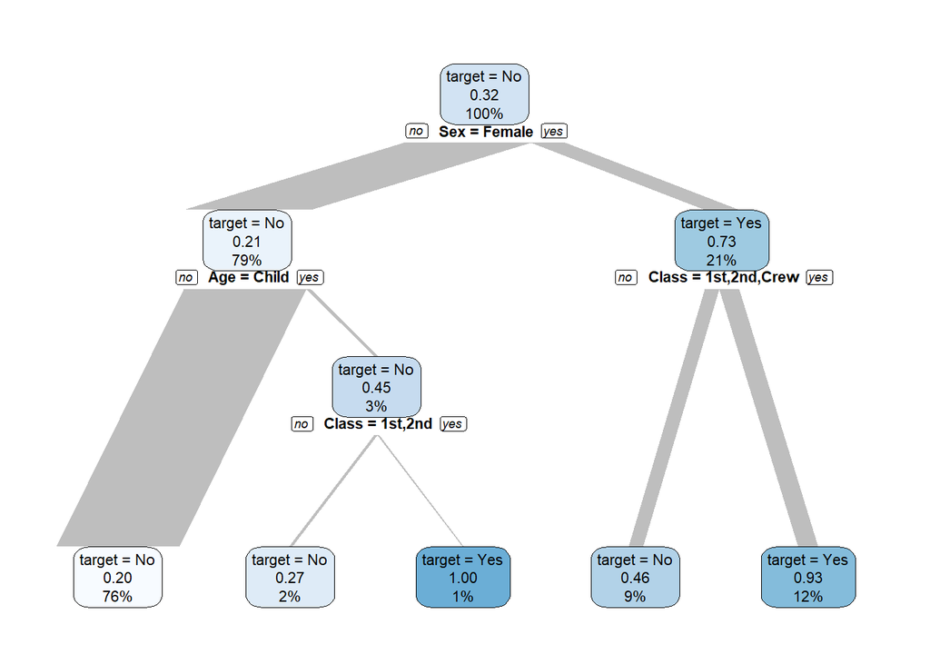

```r
titanic |> explain_tree(target = Survived, n = n)
```

We see that Sex and Class can give a good explanation who are more likely to survive.

Sex = Male: 21% survived (79% of all observations) Sex = Female & Class = 3rd: 46% survived (9% of all observations) Sex = Female & Class <> 3rd: 93% survived (12% of all observations)

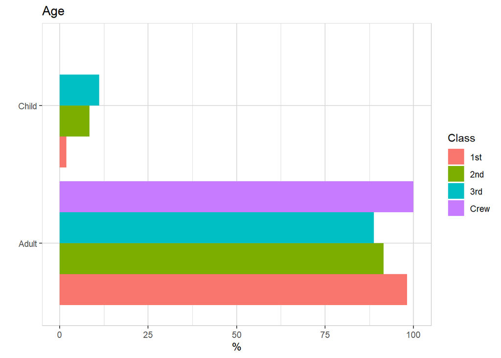

```r
titanic |> explore(Age, target = Class, n = n)
```

# 1 logit

```r
## Load Titanic library to get the dataset
library(titanic)

## Load the datasets
data("titanic_train")
data("titanic_test")


## Setting Survived column for test data to NA
titanic_test$Survived <- NA

## Combining Training and Testing dataset
complete_data <- rbind(titanic_train, titanic_test)

## Check data structure
str(complete_data)
```

```
'data.frame':   1309 obs. of  12 variables:
 $ PassengerId: int  1 2 3 4 5 6 7 8 9 10 ...
 $ Survived   : int  0 1 1 1 0 0 0 0 1 1 ...
 $ Pclass     : int  3 1 3 1 3 3 1 3 3 2 ...
 $ Name       : chr  "Braund, Mr. Owen Harris" "Cumings, Mrs. John Bradley (Florence Briggs Thayer)" "Heikkinen, Miss. Laina" "Futrelle, Mrs. Jacques Heath (Lily May Peel)" ...
 $ Sex        : chr  "male" "female" "female" "female" ...
 $ Age        : num  22 38 26 35 35 NA 54 2 27 14 ...
 $ SibSp      : int  1 1 0 1 0 0 0 3 0 1 ...
 $ Parch      : int  0 0 0 0 0 0 0 1 2 0 ...
 $ Ticket     : chr  "A/5 21171" "PC 17599" "STON/O2. 3101282" "113803" ...
 $ Fare       : num  7.25 71.28 7.92 53.1 8.05 ...
 $ Cabin      : chr  "" "C85" "" "C123" ...
 $ Embarked   : chr  "S" "C" "S" "S" ...
```

```r
## Missing values imputation
complete_data$Embarked[complete_data$Embarked==""] <- "S"
complete_data$Age[is.na(complete_data$Age)] <- median(complete_data$Age,na.rm=T)

## Removing Cabin as it has very high missing values, passengerId, Ticket and Name are not required
library(dplyr)
titanic_data <- complete_data %>% select(-c(Cabin, PassengerId, Ticket, Name))

## Converting "Survived","Pclass","Sex","Embarked" to factors
for (i in c("Survived","Pclass","Sex","Embarked")){
  titanic_data[,i]=as.factor(titanic_data[,i])
}

## Create dummy variables for categorical variables sin el plaquete dummies Pclass","Sex","Embarked"
```

```r
## Splitting training and test data
train <- titanic_data[1:667,]
test <- titanic_data[668:889,]

## Model Creation
model <- glm(Survived ~.,family=binomial(link='logit'),data=train)

## Model Summary
summary(model)
```

```
Call:
glm(formula = Survived ~ ., family = binomial(link = "logit"),
    data = train)

Coefficients:
             Estimate Std. Error z value Pr(>|z|)
(Intercept)  3.911260   0.561941   6.960 3.40e-12 ***
Pclass2     -0.872836   0.355051  -2.458 0.013958 *
Pclass3     -2.175104   0.359365  -6.053 1.42e-09 ***
Sexmale     -2.677814   0.226863 -11.804  < 2e-16 ***
Age         -0.031671   0.008945  -3.540 0.000399 ***
SibSp       -0.248975   0.123365  -2.018 0.043570 *
Parch       -0.091603   0.141950  -0.645 0.518718
Fare        -0.001397   0.003179  -0.440 0.660254
EmbarkedQ    0.101747   0.425559   0.239 0.811036
EmbarkedS   -0.431447   0.271693  -1.588 0.112288
---
Signif. codes:  0 '***' 0.001 '**' 0.01 '*' 0.05 '.' 0.1 ' ' 1

(Dispersion parameter for binomial family taken to be 1)

    Null deviance: 891.99  on 666  degrees of freedom
Residual deviance: 605.78  on 657  degrees of freedom
AIC: 625.78

Number of Fisher Scoring iterations: 5
```

```r
anova(model, test="Chisq")
```

```
Analysis of Deviance Table

Model: binomial, link: logit

Response: Survived

Terms added sequentially (first to last)

         Df Deviance Resid. Df Resid. Dev  Pr(>Chi)
NULL                       666     891.99
Pclass    2   66.088       664     825.91 4.458e-15 ***
Sex       1  197.978       663     627.93 < 2.2e-16 ***
Age       1    8.986       662     618.94  0.002721 **
SibSp     1    8.114       661     610.83  0.004393 **
Parch     1    0.998       660     609.83  0.317889
Fare      1    0.044       659     609.79  0.834588
Embarked  2    4.003       657     605.78  0.135132
---
Signif. codes:  0 '***' 0.001 '**' 0.01 '*' 0.05 '.' 0.1 ' ' 1
```

```r
## Predicting Test Data
result <- predict(model, newdata= test, type='response')
result <- ifelse(result > 0.5,1,0)

## Confusion matrix and statistics
library(caret)
#confusionMatrix(data=result, reference=test$Survived)
```